# Data Viz Makeovers

Stat 365: Statistical Communication

## Monday, May 6th

Today we will…<sup>1</sup>

- Effective Visuals
- Presenting Visuals
- Let’s discuss!
[^1]: Material for today’s lecture is from [Brianna Haggeseth](https://www.macalester.edu/mscs/facultystaff/brianna-heggeseth/)

## Effective visuals

- Be ethical and honest
- Be accessible (alternative text, double encoding)
- Consider geometry choice (easy or hard to perceive?)
- Consider color choices (color blind friendly? cultural associations?)
- Facilitate comparison (GESTALT)
  - e.g. position through order on axis or faceting, calculate and present the difference or ratio
- Use contrasts to draw attention

## Effective Visuals

- [Storytelling with Data: Makeovers](https://www.storytellingwithdata.com/blog?category=Makeovers)
- [Post Blog: Effective visuals for Credible Data Driven Decision Making](https://posit.co/blog/effective-visualizations-for-credible-data-driven-decision-making/)

## When presenting your visualization,

- Explain the motivation for the visualization.
  - What is the question you are answering, and why is it important?
  - What context does the audience need to understand the visual? (W’s?)

## When presenting your visualization,

- Take a moment to give people their bearings.
  - What aspects of the visual should you explain to provide necessary orientation?
  - Walk through guides (axes, color legend, etc.)

## When presenting your visualization,

- Hone in on one or two interesting data points and tell the story behind them.
  - Explain how the visual aspects of the viz reflect that story (this reinforces how they should interpret the viz).

## When presenting your visualization,

- Explain the overall trends or takeaways.
  - What are the implications for them? Why does it matter?
  - What comparison are you wanting to highlight?

## When presenting your visualization,

- Speak slowly
  - It takes people some time to wrap their heads around a new viz.

## Childcare Data Viz Original

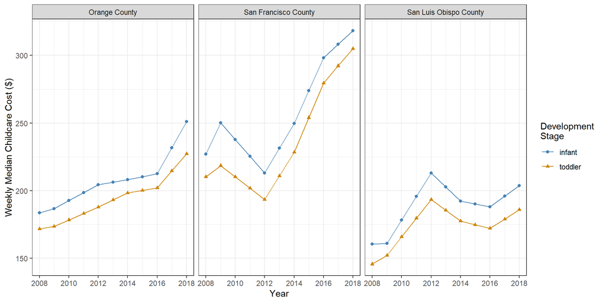

The figure shows an overall increasing trend in weekly median childcare costs from 2008 to 2018 across Orange County, San Fransisco County, and San Luis Obispo County. Further, the weekly median childcare cost is consistently higher for infants than for toddlers.

## Childcare Data Viz Makeover

Main message: Compare childcare costs between infants and toddlers in California.

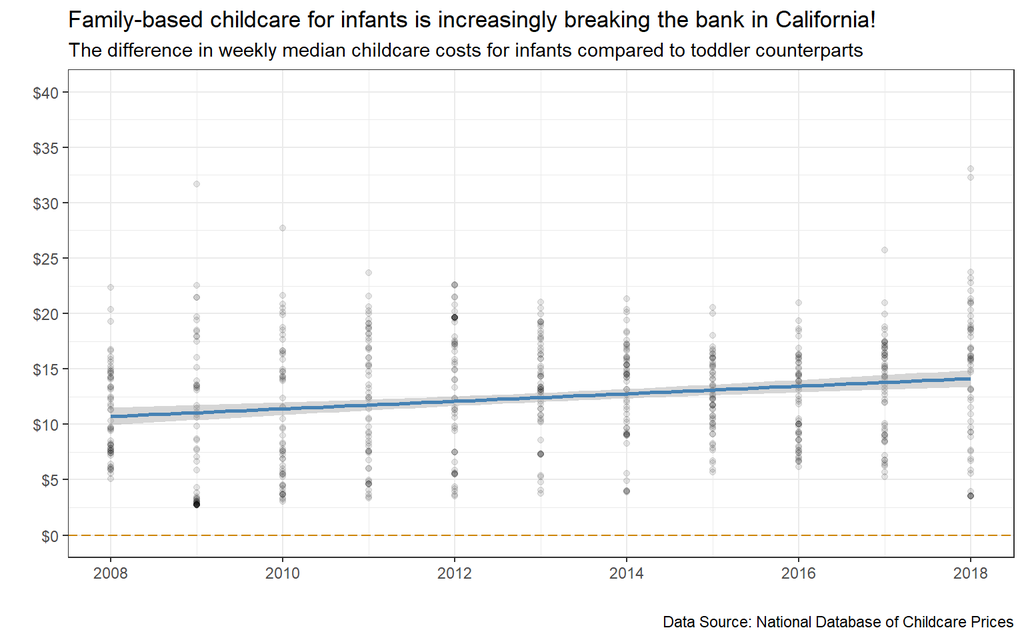

```r
ca_childcare |>
  pivot_wider(id_cols = c("county_name", "study_year"),
              names_from = "development_stage",
              values_from = "median_weekly_childcare_cost") |>
  mutate(difference = infant - toddler) |>
  ggplot(aes(x = study_year,
             y = difference)
  ) +
  geom_point(alpha = 0.1) +
  geom_smooth(method = "lm", color = "steelblue") +
  geom_hline(yintercept = 0, linetype = "longdash", color = "orange3") +
  # geom_line() +
  scale_x_continuous(breaks = seq(2008, 2018, 2)) +
  scale_y_continuous(limits = c(0, 40), breaks = seq(0, 40, 5), labels = scales::dollar) +
  # scale_color_manual(values = c("steelblue", "orange3")) +
  theme_bw() +
  labs(x = "",
       y = "",
       title = "Family-based childcare for infants is increasingly breaking the bank in California!",
       subtitle = "The difference in weekly median childcare costs for infants compared to toddler counterparts",
       caption = "Data Source: National Database of Childcare Prices"
       )
```

## In your project groups,

- present your visualization (2 minutes)
- discuss as a group ways of improving the visualization to make it more effective (8 minutes)
  - comment on the effective features of the graphic first
  - offer concrete suggestions about the visualization
  - different geometries (points, lines, bars, etc.)
  - different colors, consider faceting, position, etc.
  - show variability for quantitative measures

## To do

**One Number Story Mini-Project**

- Work toward live revisions

**Data Narrative Visualization**

- Make improvements as discussed in class.
- Final submission due Thursday, 5/9 at 11:59pm

**Read Dengue Paper**

- for class this Wednesday